# Advanced Geovisualization Lab 1

Natalie Britton

2022-11-05

# Overview

This R Markdown was created to give a basic tutorial on how to create geovisualizations and analyze spatial data in R. For this tutorial, we will be investigating the spatial patterns of illegal waste dumping in Pittsburgh, Pennsylvania. Determining where illegal dumping is occurring can have huge justice implications for policy making to counteract this activity. You will need to download [this data](https://data.wprdc.org/dataset/allegheny-county-illegal-dump-sites) from the Western PA Regional Data Center to follow along. On this site you can also find helpful metadata.

# Importing and inspecting the data

You will need these packages.

```r
library(ggplot2)
library(sf)
library(tidyverse)
```

Load the data (make sure to use your own directory when calling the file).

```r
csv <- read_csv("C:/Users/nbrit/OneDrive/Desktop/GeoVis Labs/Adv Lab 1/illegaldumpsites (1).csv")
```

```
## ──────────────────────────────────────────────────────── Delimiter: "," chr
## (5): site_name, Status, City, Neighborhood, location_description dbl (4):
## estimated_tons, latitude, longitude, ...9
```

```r
head(csv)
```

```
## # A tibble: 6 × 9
##   site_name         Status   City  Neigh…¹ estim…² locat…³ latit…⁴ longi…⁵  ...9
##   <chr>             <chr>    <chr> <chr>     <dbl> <chr>     <dbl>   <dbl> <dbl>
## 1 St. Martin Street Surveyed Pitt… Allent…     0.5 <NA>       40.4   -80.0    NA
## 2 Brosville Street  Surveyed Pitt… Allent…     3   <NA>       40.4   -80.0    NA
## 3 McCain Street     Surveyed Pitt… Allent…     1   <NA>       40.4   -80.0    NA
## 4 Ceres Way         Surveyed Pitt… Allent…     0.5 <NA>       40.4   -80.0    NA
## 5 Eureka Street     Complet… Pitt… Allent…     0.1 <NA>       40.4   -80.0    NA
## 6 222 Walter Street Complet… Pitt… Allent…     5   dump i…    40.4   -80.0    NA
## # … with abbreviated variable names ¹Neighborhood, ²estimated_tons,
## #   ³location_description, ⁴latitude, ⁵longitude
```

```r
dumping_sites <- st_as_sf(csv, coords = c("longitude", "latitude"), crs = 32129)
```

Let’s plot our data on a basic map.

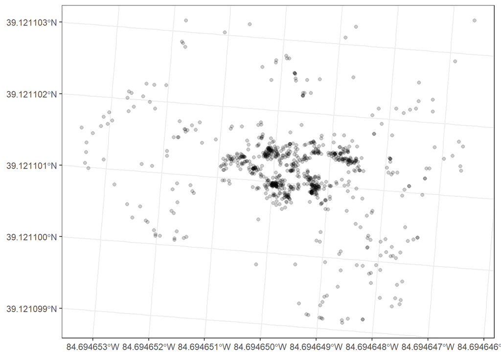

```r
ggplot()+
  geom_sf(data = dumping_sites, fill = NA, alpha = .2) +
  theme_bw()
```

We can also use leaflet to produce a quick interactive map of our dumping sites. By choosing world imagery, we can observe the context on the ground of each of our dumping sites. Check out [this website](https://bookdown.org/nicohahn/making_maps_with_r5/docs/leaflet.html) to learn more about how to use leaflet.

```r
library(leaflet)
m <- leaflet() %>%
  addProviderTiles(
    "Esri.WorldImagery",
    group = "Esri.WorldImagery"
  ) %>%
  addMarkers(data = dumping_sites, popup=paste("Site Name: ", dumping_sites$site_name))
m
```

[interactive chart not shown]

# Analyzing and mapping the data

Now, let’s start to analyze our data. Here is a table of each of our variables that we have to work with:

| Variable | Description |
| --- | --- |
| site_name | Name given to the site for easy identification Often the site name is given based off the street the site is located on |
| Status | All sites have been surveyed, if the status is completed it means that the site has been cleaned up |
| City |  |
| Neighborhood | in cases of small towns or cities the neighborhood may be the same as the previous field “City” |
| estimated_tons | The amount of tons the surveyor estimated the site to have This is done with a visual inspection |
| location_description | A description of the location of the dump site if it is particularly hard to see/ find from the road Many of the sites are left blank in this section |

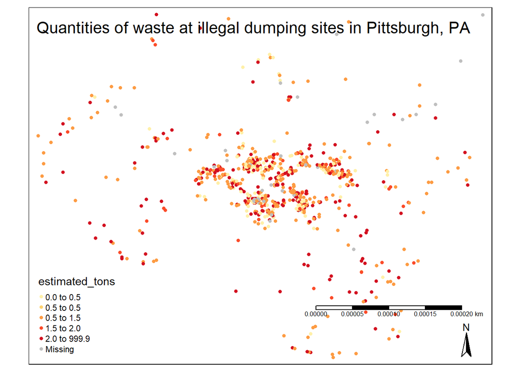

```r
library(tmap)
## Add the data - these are specific to the vector or raster
tm_shape(dumping_sites) +
  ## which variable, is there a class interval, palette, and other options
  tm_symbols(col='estimated_tons',
             style='quantile',
             palette = 'YlOrRd',
             border.lwd = NA,
             size = 0.1) +
  tm_layout(title = "Quantities of waste at illegal dumping sites in Pittsburgh, PA") +
  tm_scale_bar() +
  tm_compass()
```

The title and scale bar look pretty bad all mashed up into the map. Let’s fix that by redefining the extent of our map so that the title fits more comfortably within the boundaries. We can do this by extending the corners of the bounding box (bbox), the coordinates that define the extent to our map. I extended the top right slightly more than I do the bottom left (by 2/5 of the range vs. 1/10 of the range) to make room for the legend.

I also made the points slightly larger and a bit transparent (using the alpha argument) so that the points cover more of the map and look more cohesive. Lastly, with the credits function, you can add author and data source information.

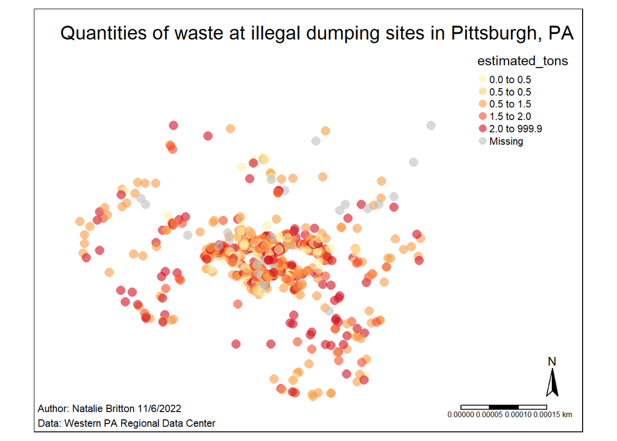

```r
# extract the current bounding box
bbox_new <- st_bbox(dumping_sites)

xrange <- bbox_new$xmax - bbox_new$xmin # range of x values
yrange <- bbox_new$ymax - bbox_new$ymin # range of y values

bbox_new[1] <- bbox_new[1] - (0.1 * xrange) # xmin - left
bbox_new[3] <- bbox_new[3] + (0.4 * xrange) # xmax - right
bbox_new[2] <- bbox_new[2] - (0.1 * yrange) # ymin - bottom
bbox_new[4] <- bbox_new[4] + (0.4 * yrange) # ymax - top

bbox_new <- bbox_new %>%  # take the bounding box ...
  st_as_sfc() # ... and make it a sf polygon

tm_shape(dumping_sites, bbox = bbox_new) +
  tm_symbols(col='estimated_tons',
             style='quantile',
             palette = 'YlOrRd',
             border.lwd = NA,
             size = .5,
             alpha = .6) +
  tm_layout(legend.position = c("right", "top"),
            title = "Quantities of waste at illegal dumping sites in Pittsburgh, PA",
            title.position = c('right', 'top')) +
  tm_compass() +
  tm_scale_bar(width = .15) +
  tm_credits("Author: Natalie Britton 11/6/2022\nData: Western PA Regional Data Center",
             position = c("LEFT", "BOTTOM"))
```

This map isn’t revealing any obvious spatial patterns in the size of dumping sites. Let’s inspect a histogram of estimated tons to consider how we could better visualize this data. We need to trim the data set because as we saw in the map above, there is an obvious placeholder value (999.9) that does not fit with the rest of the values that will throw off our histogram. The easiest way to do this is to remove outliers using the interquartile range (IQR) via the “trim” function below.

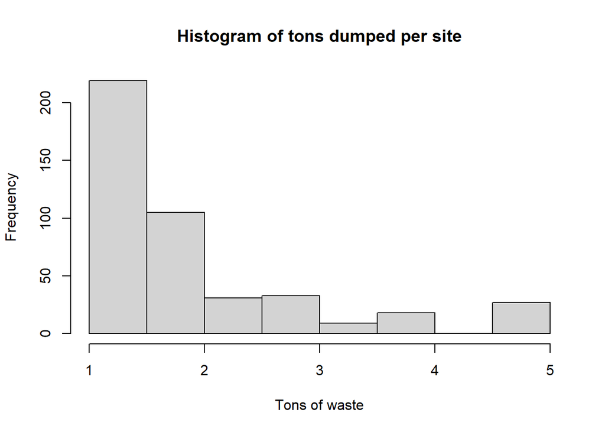

```r
trim <- function(x){
  x[(x > mean(x)-1.5*IQR(x)) & (x < mean(x)+1.5*IQR(x))]
}

trim_tons <- trim(na.omit(dumping_sites$estimated_tons))

hist(trim_tons, main = "Histogram of tons dumped per site", xlab = "Tons of waste")
```

Now that we see that anything above 4 tons is pretty rare, let’s find only those sites. We can use the mutate() function in the dplyr package to add a new column the end of our data frame. We’re using ifelse() to determine if the estimated tons is >= 4, and if so a value of TRUE will be returned in the new column “high_tons”. Next, we can visualize if “high_tons” is true or false for each point.

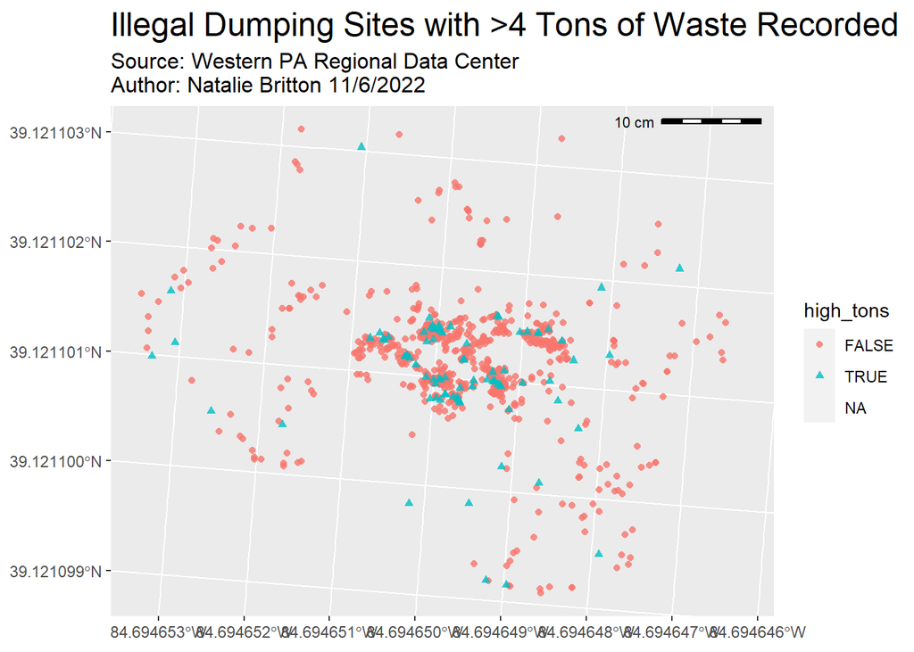

```r
library(dplyr)
library(ggspatial)

dumping_sites %>%
  #mutate adds a new variable to the end of that dataframe
    mutate(high_tons = ifelse(estimated_tons >= 4, TRUE, FALSE)) %>%
ggplot() +
  geom_sf(aes(color=high_tons, shape = high_tons),
    fill = NA, alpha = .8) +
  labs(
    title = "Illegal Dumping Sites with >4 Tons of Waste Recorded",
    subtitle = "Source: Western PA Regional Data Center\nAuthor: Natalie Britton 11/6/2022") +
   theme(plot.title = element_text(size=18),
        plot.subtitle = element_text(size=12)) +
        annotation_scale(location = "tr", line_width = 1, height=unit(0.1, "cm"))
```

It doesn’t look like the larger dumping sites are very spatially correlated, but let’s see how dumping varies across a few notable neighborhoods using a boxplot. We can use the filter function (also in the dplyr package) to group estimated_tons by Neighborhood for an easy comparison.

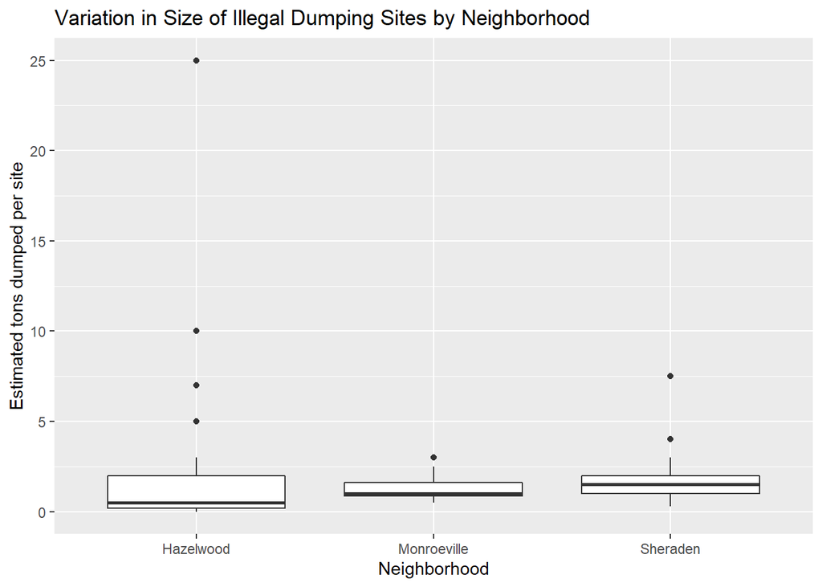

```r
dumping_sites %>%
  filter(Neighborhood ==  'Monroeville' | Neighborhood == 'Hazelwood' | Neighborhood == 'Sheraden') %>%
  ggplot(aes(x=Neighborhood, y=estimated_tons)) +
  geom_boxplot() +
  ggtitle("Variation in Size of Illegal Dumping Sites by Neighborhood") +
  xlab("Neighborhood") +
  ylab ("Estimated tons dumped per site")
```

Finally, let’s check on the cleanup status of each of the sites using a pie chart and accompanying interactive map.

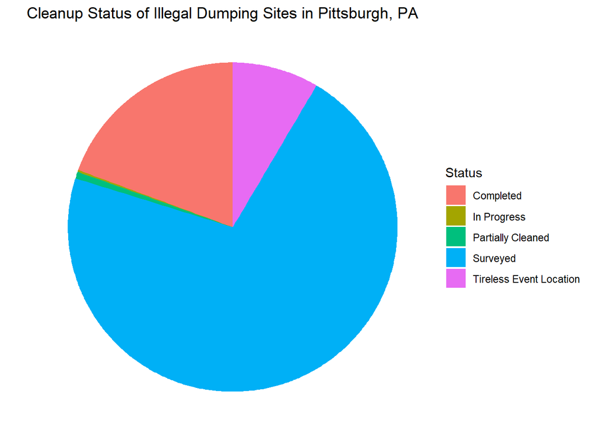

```r
ggplot(dumping_sites, aes(x = "", y=Status, fill=Status)) +
  geom_bar(stat="identity", width=1) +
  coord_polar("y", start=0) +
  theme_void() +
  ggtitle("Cleanup Status of Illegal Dumping Sites in Pittsburgh, PA")
```

```r
library(leaflet)
m <- leaflet() %>%
  addProviderTiles(
    "Esri.WorldImagery",
    group = "Esri.WorldImagery"
  ) %>%
  addMarkers(data = dumping_sites, popup=paste("Cleanup Status: ", dumping_sites$Status))
m
```

[interactive chart not shown]